# Quản lý rủi ro tai nạn giao thông tại Việt Nam

Một bài trình bày giáo dục về dữ liệu, dự đoán và quyết định an toàn giao thông

Author

Your Name

Published

10 tháng 10, 2026

**TipỨng dụng tương tác**

[Mở ứng dụng Streamlit](https://traffic-accident-severity-cvz7oug8kg8mbftwnn8e6r.streamlit.app/) để tự chọn hoàn cảnh của một vụ tai nạn và xem mô hình dự đoán.

## Tóm tắt

- **Câu hỏi:** chỉ nhìn vào *hoàn cảnh* của một vụ tai nạn (trời sáng hay tối, đâm vào gì, người lái bao nhiêu tuổi…), máy tính có đoán được vụ đó có **nghiêm trọng** (có người bị thương nặng hoặc tử vong) hay không?

- **Dữ liệu:** 12.316 bản ghi tai nạn có thật ở Addis Ababa (Ethiopia), một thành phố có giao thông hỗn hợp xe máy, ô tô, xe buýt và người đi bộ, khá giống các thành phố Việt Nam.

- **Phát hiện rõ nhất:** ban đêm **không có đèn đường**, tỉ lệ vụ nghiêm trọng là **28%**, gần **gấp đôi** ban ngày (15%). Ban đêm *có* đèn đường thì gần an toàn như ban ngày.

- **Bài học quản lý:** mô hình giúp minh họa cách sàng lọc rủi ro và chọn mức cảnh báo, nhưng vẫn bỏ sót và báo nhầm. Nó không thay thế dữ liệu Việt Nam, khảo sát hiện trường hay quyết định của chuyên gia.

## 1 Vì sao làm dự án này?

Tai nạn giao thông là một vấn đề rất gần gũi ở Việt Nam. Dự án này muốn thử trả lời một câu hỏi: **nếu biết hoàn cảnh của một vụ tai nạn, ta có thể đoán nó nghiêm trọng đến đâu không?** Nếu được, ta sẽ biết những hoàn cảnh nào nguy hiểm nhất để ưu tiên phòng tránh.

Bước đầu tiên là tìm dữ liệu tai nạn của Việt Nam, nhưng hồ sơ tai nạn ở Việt Nam chưa được công bố công khai. Vì vậy dự án dùng dữ liệu của **cảnh sát thành phố Addis Ababa, thủ đô Ethiopia (2017–2020)**. Lý do chọn: giao thông ở đây có **xe máy, xe ba bánh, xe buýt, ô tô và người đi bộ dùng chung đường**, giống Việt Nam hơn nhiều so với dữ liệu nổi tiếng của Mỹ hay Anh (chủ yếu ô tô trên đường cao tốc). Điều này **không** có nghĩa là giao thông hai nước giống hệt nhau, chỉ là *loại vấn đề* gần nhau hơn.

## 2 Dữ liệu ghi lại những gì?

Mỗi bản ghi mô tả một vụ tai nạn bằng 24 thông tin có trước hoặc ngay lúc va chạm, chia thành các nhóm:

- **Người lái:** tuổi, giới tính, trình độ học vấn, kinh nghiệm lái xe.

- **Phương tiện:** loại xe, số năm đã sử dụng, xe có lỗi kỹ thuật không.

- **Con đường:** khu vực, loại giao lộ, làn đường, mặt đường, hình dạng con đường.

- **Môi trường:** ánh sáng, thời tiết, giờ, thứ trong tuần.

- **Va chạm:** kiểu va chạm, số xe liên quan, xe đang làm gì, nguyên nhân.

### 2.1 Không để lộ đáp án

Dữ liệu còn có những cột ghi lại **sau** tai nạn: ai bị thương, bị thương nặng đến đâu, có bao nhiêu người thương vong. Dự án **không** cho mô hình xem những cột này. Nếu cho mô hình biết “có người bị thương nặng” rồi hỏi “vụ này có nghiêm trọng không”, nó sẽ trả lời rất giỏi nhưng **vô dụng**, giống như được xem đáp án trước khi làm bài. Một hệ thống phòng tránh tai nạn chỉ có thể dùng thông tin có **trước** khi tai nạn xảy ra.

### 2.2 Phần lớn tai nạn chỉ gây thương tích nhẹ

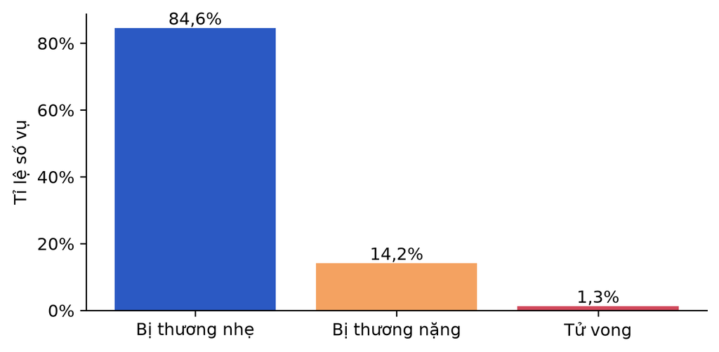

Chỉ **1,3%** số vụ có người tử vong, tức khoảng 158 vụ. Quá ít để máy học nhận ra riêng nhóm này: khi thử, mô hình gần như không phát hiện được vụ tử vong nào. Vì vậy dự án **gộp “bị thương nặng” và “tử vong” thành một nhóm: nghiêm trọng** (khoảng 15% số vụ). Câu hỏi trở thành: *vụ này có nghiêm trọng không?* Đây vẫn là câu hỏi hữu ích: một hệ thống cảnh báo cần biết vụ nào *nguy hiểm*, không nhất thiết phải phân biệt nặng với tử vong.

## 3 Dữ liệu nói gì?

Trước khi dùng máy học, hãy tự nhìn vào dữ liệu. Với mỗi nhóm (ví dụ: *ban đêm, không có đèn đường*), ta tính **tỉ lệ nghiêm trọng**: trong 100 vụ thuộc nhóm đó, có bao nhiêu vụ nghiêm trọng. Đường gạch đứt là mức trung bình. Nhóm có dưới 30 vụ được bỏ qua vì quá ít để tin.

### 3.1 Thiếu đèn đường, không phải “ban đêm”, mới là điều nguy hiểm

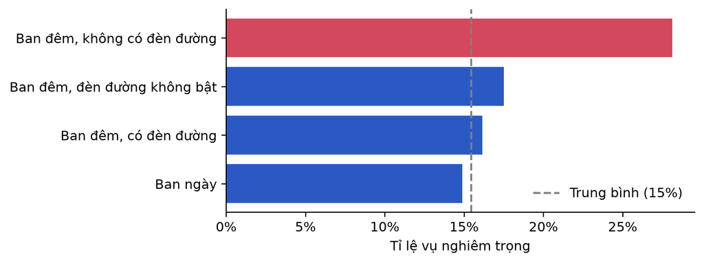

Đây là phát hiện rõ ràng và hữu ích nhất của dự án. Ban đêm **không có đèn đường**: **28%** số vụ là nghiêm trọng, gần **gấp đôi** ban ngày (15%). Nhưng ban đêm **có đèn đường** chỉ là 16%, gần bằng ban ngày. Vậy điều nguy hiểm là **thiếu ánh sáng**, và đó là điều có thể khắc phục bằng cách lắp đèn đường.

### 3.2 Hình chữ U: một xe, hoặc rất nhiều xe

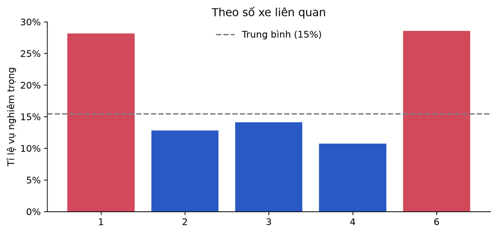

Tai nạn **chỉ một xe** thường là mất lái hoặc tông vào người đi bộ, và thường nặng. Tai nạn hai, ba xe thường là va quẹt khi đang di chuyển chậm, nên nhẹ hơn. Khi số xe rất lớn, nguy hiểm lại tăng. Biểu đồ có **hình chữ U**.

Điều thú vị: nếu chỉ tính **hệ số tương quan** thông thường (một con số đo xem hai thứ có cùng tăng, cùng giảm không), ta sẽ thấy số xe *gần như không liên quan* đến mức độ nghiêm trọng. Lý do là hệ số tương quan chỉ đo xu hướng **theo một chiều**: nửa “đi xuống” và nửa “đi lên” của chữ U triệt tiêu nhau. Bài học: **luôn vẽ biểu đồ**, đừng chỉ tin vào một con số.

### 3.3 Người lái rất trẻ và người lái lớn tuổi

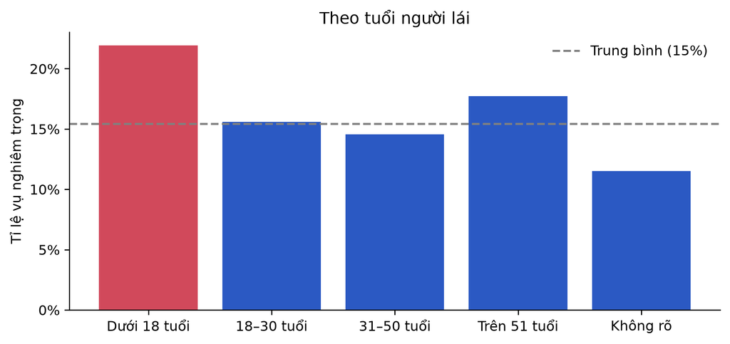

Lại một hình chữ U: người lái **dưới 18 tuổi** (22%) và **trên 51 tuổi** (18%) có tỉ lệ nghiêm trọng cao hơn nhóm 31–50 tuổi (15%). Điều này khớp với nghiên cứu an toàn giao thông trên thế giới: người trẻ thiếu kinh nghiệm, người lớn tuổi phản xạ chậm hơn và cơ thể dễ tổn thương hơn. Lưu ý nhóm dưới 18 tuổi khá nhỏ, nên con số của nhóm này kém chắc chắn hơn.

### 3.4 Theo giờ trong ngày

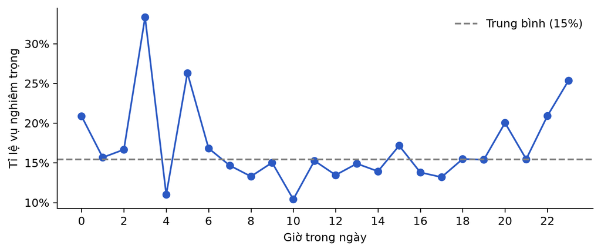

Tai nạn ban đêm và rạng sáng nặng hơn, khớp với phát hiện về đèn đường. Hai cách nhìn khác nhau (ánh sáng và giờ) cùng chỉ về một hướng, nên ta tin hơn rằng đây là quy luật thật chứ không phải ngẫu nhiên.

**NoteLiên hệ không phải là nguyên nhân**

Những con số trên cho thấy **mối liên hệ**, chưa chứng minh **nguyên nhân**. Ví dụ, đường không có đèn có thể cũng là đường ngoại ô, nơi xe chạy nhanh hơn. Muốn chắc chắn “lắp đèn sẽ giảm tai nạn nặng” cần thêm nghiên cứu khác.

## 4 Một vụ tai nạn, nhiều dòng dữ liệu

Khi kiểm tra kỹ, dự án phát hiện **3.003 dòng** (24% dữ liệu) có cùng giờ, cùng ngày, cùng nơi, cùng thời tiết, cùng kiểu va chạm với một dòng khác. Đó là **cùng một vụ tai nạn**, được ghi mỗi xe một dòng. Bằng chứng: trong những nhóm này, mức độ nghiêm trọng giống nhau **94%** số lần, trong khi nếu là các vụ khác nhau thì chỉ khoảng 74%.

**Vì sao điều này quan trọng?** Để biết mô hình giỏi thật hay không, ta phải kiểm tra nó trên những vụ tai nạn nó **chưa từng thấy**, giống như đề thi phải khác bài tập. Nếu một dòng của vụ tai nạn nằm trong phần “học” còn dòng kia nằm trong phần “thi”, mô hình chỉ cần **nhớ** chứ không cần **hiểu**: bị **lộ đề**.

Khi chia ngẫu nhiên, điểm PR-AUC là 0,289; khi giữ nguyên từng vụ, điểm là **0,275**. Sự khác biệt cho thấy vì sao một bài kiểm tra công bằng phải ngăn cùng một vụ xuất hiện ở cả phần học và phần thi. Mọi con số trong báo cáo này đều dùng cách chia theo vụ.

## 5 Dạy máy học

### 5.1 Máy học là gì?

Hãy tưởng tượng bạn cho một người xem hàng nghìn vụ tai nạn, mỗi vụ kèm hoàn cảnh và kết quả (nghiêm trọng hay không). Dần dần người đó nhận ra quy luật: “ban đêm không đèn thì hay nặng”, “va quẹt hai xe thì thường nhẹ”… **Máy học** làm đúng điều đó, chỉ khác là máy xem được rất nhiều vụ và nhận ra cả những quy luật phức tạp, kết hợp nhiều yếu tố cùng lúc.

Kết quả của việc học gọi là **mô hình**. Đưa cho mô hình hoàn cảnh của một vụ mới, nó trả lời **khả năng** vụ đó nghiêm trọng, ví dụ 25%.

### 5.2 Chấm điểm thế nào cho công bằng?

Dữ liệu được chia làm 5 phần. Mô hình học trên 4 phần rồi làm bài thi trên phần còn lại, lặp lại cho đủ 5 phần, và cả quá trình được làm 3 lần với các cách chia khác nhau. Như đã nói, các dòng của một vụ tai nạn luôn ở cùng một phía.

**Cái bẫy “độ chính xác”:** một mô hình *lười biếng* luôn trả lời “không nghiêm trọng” sẽ đúng **85%** số lần, vì phần lớn tai nạn đều nhẹ! Nghe thì giỏi, nhưng nó không bao giờ phát hiện được vụ nghiêm trọng nào. Vì vậy dự án dùng hai điểm số khác:

- **Macro-F1** (từ 0 đến 1): đo xem mô hình giỏi *cả hai việc*: nhận ra vụ nghiêm trọng và nhận ra vụ không nghiêm trọng, rồi lấy trung bình. Mô hình lười biếng chỉ được khoảng **0,46**.

- **PR-AUC** (từ 0 đến 1): đo xem mô hình có xếp các vụ nghiêm trọng **lên trên** hay không. Đoán bừa được khoảng **0,15**.

### 5.3 Mô hình đóng vai trò gì trong quản lý?

Mô hình kết hợp nhiều cây quyết định để ước tính **khả năng** một vụ tai nạn sẽ nghiêm trọng. Kết quả giúp sàng lọc tình huống, đặt câu hỏi khảo sát và thảo luận về mức cảnh báo. Mô hình không chứng minh nguyên nhân, không tự chọn biện pháp can thiệp và không đủ cơ sở để vận hành tại Việt Nam nếu chưa được kiểm tra bằng dữ liệu địa phương.

### 5.4 Khi nào thì bật cảnh báo?

Mô hình đưa ra **khả năng** nghiêm trọng, ví dụ 25%. Ta phải chọn: từ mức nào thì **bật cảnh báo**? Vì chỉ khoảng 15% tai nạn là nghiêm trọng, mô hình hiếm khi chắc chắn trên 50%. Nếu chờ đến 50% mới cảnh báo, nó sẽ bỏ sót gần hết các vụ nghiêm trọng. Dự án chọn mức **24%**, mức cho điểm Macro-F1 cao nhất.

Với mức này, cứ **1.000 vụ tai nạn** thì có khoảng **154** vụ nghiêm trọng, và:

- mô hình **bắt được 58** vụ nghiêm trọng, **bỏ sót 96** vụ;

- mô hình bật **170** lần cảnh báo: **58** lần đúng, **112** lần **báo nhầm**.

Nghe có vẻ chưa tốt, nhưng hãy so với đoán bừa: nếu bật 170 cảnh báo một cách ngẫu nhiên, chỉ khoảng 26 lần là đúng. Mô hình đúng gấp khoảng 2,2 lần.

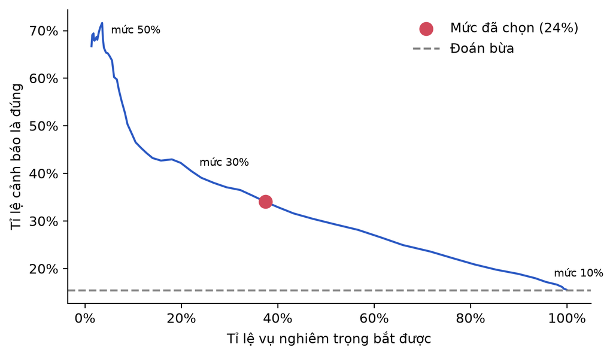

Mức thấp hơn: bắt được nhiều hơn nhưng báo nhầm nhiều hơn. Mức cao hơn: ngược lại. Chọn mức nào là **quyết định của con người**, tùy vào việc bỏ sót một vụ nghiêm trọng tệ đến đâu so với một lần báo nhầm. Nếu mô hình chỉ dùng để gợi ý vụ nào cần xem xét trước, báo nhầm thêm vài lần cũng không sao, nên có thể chọn mức thấp.

## 6 Mô hình dựa vào điều gì?

Để hiểu mô hình, dự án dùng phương pháp **SHAP**: với mỗi vụ, đo xem từng thông tin đẩy dự đoán **lên** (nguy hiểm hơn) hay **xuống** (an toàn hơn) bao nhiêu, rồi lấy trung bình trên toàn bộ dữ liệu.

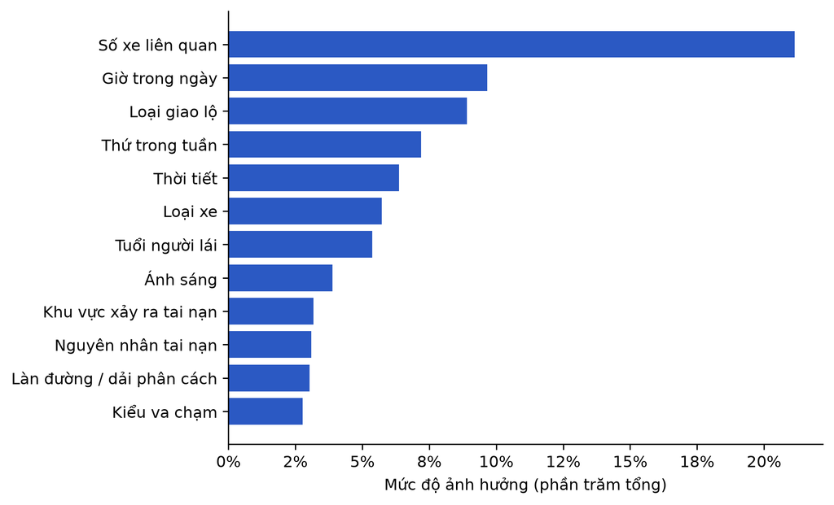

Ba thông tin mô hình dựa vào nhiều nhất là **số xe liên quan**, **giờ trong ngày**, **loại giao lộ**. Không có yếu tố nào chiếm phần lớn: mức độ nghiêm trọng của một vụ tai nạn đến từ **nhiều nguyên nhân cùng lúc**.

**Một bài học về cẩn thận.** Biểu đồ trên chỉ cho biết một yếu tố **quan trọng đến đâu**, không cho biết nó làm vụ tai nạn **nguy hiểm hơn hay an toàn hơn**. Trong phiên bản đầu của dự án, *loại giao lộ* đứng cao trong bảng xếp hạng và tác giả đã vội kết luận “ngã tư nguy hiểm”. Khi kiểm tra lại, hóa ra ngược lại: ngã tư có vạch qua đường có tỉ lệ nghiêm trọng **thấp hơn** trung bình (12% so với 15%). Luôn kiểm tra **chiều** ảnh hưởng, không chỉ **độ lớn**.

## 7 Điều này có ý nghĩa gì trong thực tế?

**Với những người quản lý giao thông:**

- **Đèn đường là biện pháp rõ ràng nhất mà dữ liệu ủng hộ.** Thiếu đèn: 28% vụ nghiêm trọng; có đèn: 16%. Rà soát những điểm hay xảy ra tai nạn mà chưa có đèn là một việc làm cụ thể.

- **Người lái rất trẻ và lớn tuổi** cần được quan tâm hơn, ví dụ qua đào tạo lái xe kỹ hơn cho người mới và kiểm tra sức khỏe định kỳ cho người lớn tuổi.

- **Một mô hình chưa hoàn hảo vẫn có ích** để sắp xếp thứ tự ưu tiên: xem xét những vụ mô hình cảnh báo trước vẫn tốt hơn xem xét ngẫu nhiên.

**Với mỗi người tham gia giao thông:**

- **Đi đường tối, không đèn, hãy giảm tốc độ và cẩn thận gấp đôi.** Chính việc *không nhìn rõ* làm tăng nguy hiểm.

- **Tai nạn một xe (tự ngã, mất lái) nguy hiểm hơn ta nghĩ:** 28% vụ một xe là nghiêm trọng, cao hơn hẳn vụ hai xe (13%).

- **Nếu bạn sắp được lái xe**, hãy nhớ nhóm người lái dưới 18 tuổi có tỉ lệ nghiêm trọng cao nhất. Kinh nghiệm đến từ thời gian, nên hãy giữ khoảng cách và tốc độ an toàn.

## 8 Giới hạn của dự án

- **Dữ liệu từ Ethiopia, không phải Việt Nam.** Những quy luật này cần được kiểm tra lại trên dữ liệu Việt Nam trước khi áp dụng.
- **Liên hệ không phải nguyên nhân.** Dữ liệu ghi lại những gì đã xảy ra, không phải một thí nghiệm có kiểm soát.
- **Thiếu những thông tin quan trọng:** tốc độ thật của xe, có đội mũ bảo hiểm hay thắt dây an toàn không, xe cứu thương đến nhanh hay chậm. Đây là lý do chính khiến mô hình còn bỏ sót và báo nhầm nhiều. Không mô hình nào đoán đúng những gì nó không được biết.
- **Dữ liệu có lỗi ghi chép:** một số cột bị bỏ trống nhiều, và có vài giá trị bị ghi sai chính tả trong dữ liệu gốc.

## 9 Kết luận

Dự án cho thấy máy học có thể hỗ trợ **sàng lọc** tình huống giao thông, nhưng kết quả luôn có bỏ sót và báo nhầm. Những bài học quan trọng nhất nằm ở việc **đặt câu hỏi đúng, kiểm tra trung thực và giữ con người trong quy trình quyết định**:

1. **Không để lộ đáp án cho mô hình:** chỉ dùng thông tin có trước tai nạn.

2. **Chấm điểm công bằng:** một vụ tai nạn không được nằm cả trong bài học lẫn đề thi.

3. **Đừng tin “độ chính xác” khi dữ liệu lệch:** một mô hình lười biếng cũng đúng 85%.

4. **Luôn vẽ biểu đồ:** hệ số tương quan bỏ qua những quy luật hình chữ U.

5. **Kiểm tra chiều ảnh hưởng**, không chỉ độ lớn.

6. **Thử nghiệm bằng dữ liệu Việt Nam** trước khi cân nhắc bất kỳ ứng dụng thực tế nào.

Và phát hiện có ích nhất lại không cần đến máy học: **thiếu đèn đường gần như nhân đôi nguy cơ tai nạn nghiêm trọng**.

## Câu hỏi suy ngẫm

1. Nếu bạn là người quản lý giao thông và chỉ có tiền cho một biện pháp, bạn sẽ chọn gì? Dữ liệu nào ủng hộ lựa chọn của bạn?
2. Vì sao một mô hình luôn trả lời “không nghiêm trọng” lại có “độ chính xác” cao? Hãy nghĩ một ví dụ khác trong đời sống có cùng cái bẫy này.
3. Nếu Việt Nam công bố dữ liệu tai nạn, bạn muốn dữ liệu đó ghi thêm thông tin gì để mô hình đoán tốt hơn?
4. Bỏ sót một vụ nghiêm trọng và báo nhầm một vụ nhẹ, điều nào tệ hơn? Câu trả lời có thay đổi tùy người dùng mô hình không?